# Simulating infectious diseases with R

Daniel Suh

[figure not shown]

### About Myself

- My research interest is the transmission of generalist parasites
- I use `R` in my research to:
  - organize data
  - run simulations
  - perform statistical analysis
  - make websites
  - write manuscripts
- I mostly work with mathematical models, large scale host-parasites association databases, and the daphnia model system.
- My contact info is daniel.suh@uga.edu

### Outline

**You should be able to…**

- code using best practices
- create an HTML doc with code and commentary
- write a function
- calculate summary statistics of a dataset
- create a figure from data

**You will be able to…**

- write a mathematical model in `R`
- numerically solve model using `lsoda` from the package `deSolve`
- graphically represent transmission dynamics

### Agenda

1. Modeling Concepts
2. Review of functions
3. Converting ODEs to R code
4. Simulate exponential growth of a population

   *Break*
5. Simulate an SIR model
6. Iterations in `R`
7. Wrap Up

### Introduction to ODE models

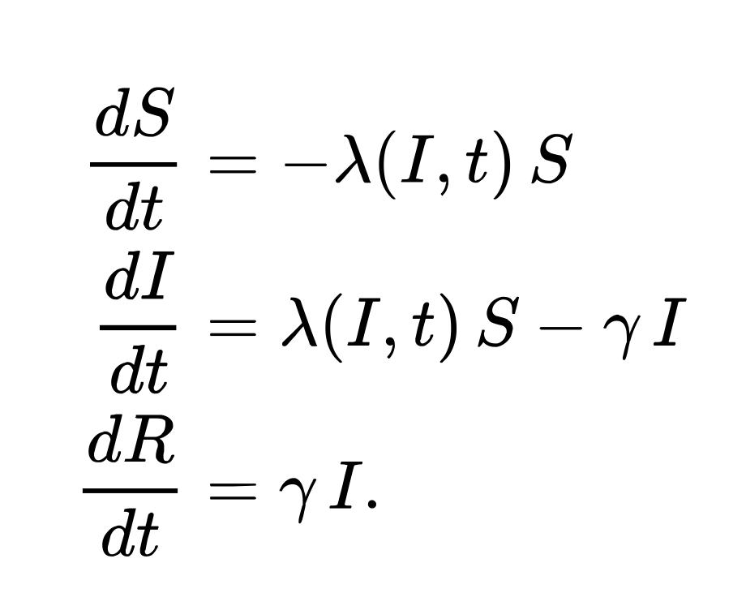

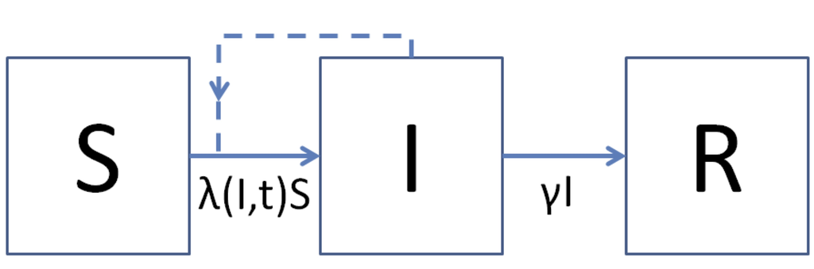

### Terminology of ODE models

# \( \frac{dN}{dt} = rN \)

What is (are) the

- state variable?
- parameter(s)?

### Key points from the reading

- What's the advantage of modeling infectious diseases?
- What are the different model types?
  - continuous vs. discrete time
  - stochastic vs. deterministic
- How would you categorize the SIR model presented?
- What is \( R_0 \) and how is it used?
- What does it mean to *solve* an ODE? how is it done?

### 2. Anatomy of a function

```r
FunctionName <- function(argument1, argument2, ...){
  #some analysis
  return(outputOfFunction)
}
```

### Example of a function

```r
 PrevByParType <- function(dataset){
  dataset %>%
    drop_na(Prevalence) %>%
    group_by(Group) %>%
    summarise(MeanPrev = mean(Prevalence), SdErrPrev = sd(Prevalence)/sqrt(n()))
 }

PrevByParType(gmp)
```

### 3. Connecting concepts to code

Based on the reading we know that ordinary differential equations (ODE) can be solved numerically by calculating the state variable at some time in the future. If the state is changing quickly, then the step size needs to be smaller to retain accuaracy.

**This is called the Euler method.**

### Euler method in R

ODEs can be solved in `R` using the `lsoda` function in the `deSolve` package.

The `lsoda()` functions has specific format requirements.

Open the W3.Rproj to start today's exercise.

### Step 1. Install and load deSolve package

```r
# install package (if not already)
install.packages("deSolve")

# load library
library(deSolve)
```

### Step 2. Pull up lsoda manual page

Use the `?` search function

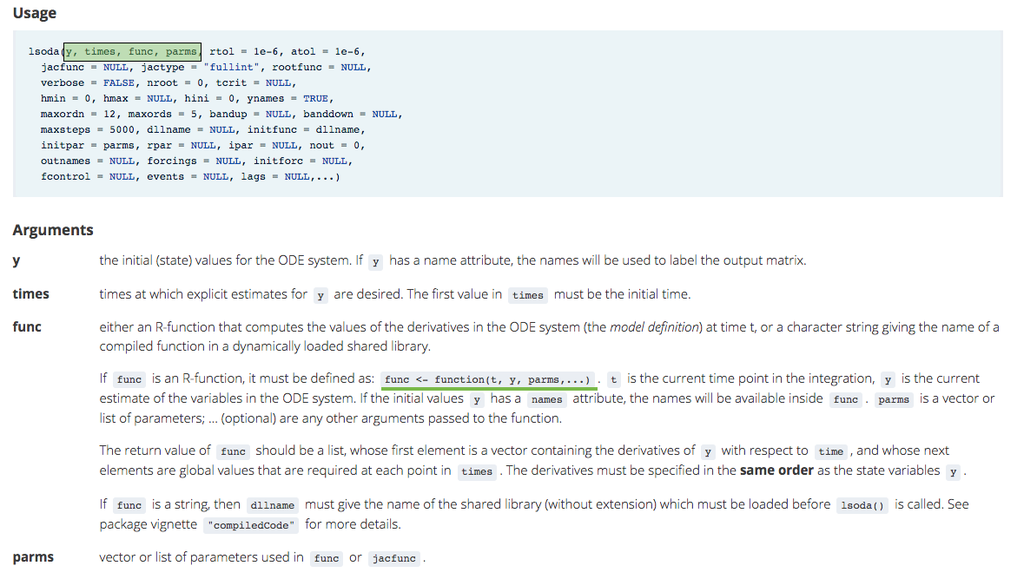

### lsoda arguments

Take a few minutes to decide what do the first 4 arguments mean

- y
- times
- func
- params

### lsoda arguments

What do the first 4 arguments mean?

- y : Starting values for the state variable(s)
- times : times that you want the state variable(s) recorded
- func : function describing how the state variable changes (Model)
- params : parameter values used in the model

What are the special instructions for the func argument?

### func for lsoda

The manual states that the function should be defined as:

```r
func <- function(t,y,parms)
```

Let's work to write the exponential growth model \( \frac{dN}{dt}= rN \) in this form

switch over to `W3_Exercise.Rmd` to run model and plot solution.

# Break

### Simulating an SIR model

work in groups of 2-3 to build an SIR model and simulate data

Steps:

1. Using ExponentialGrowth as a guide write a `DensityDepSIR()`
2. Run a simulation using the parameter values (beta, gamma) and initial state conditions (S=,I=,R=)
3. Plot the simulation

If your group finishes move onto exploring parameter values.

### Challenge: Parameter values of an SIR

Once you have a working SIR model, simulate outbreaks with different parameter values.

Explore the impact of the \( \beta \) and \( \gamma \) values on the size and duration of the outbreak.

- What happens when \( \gamma \) is increased?
- What happens when \( \beta \) is increased?
- What happens when the ratio of is held constant but the absolute values change?

Are the changes what you expected? How would changing \( \gamma \) or \( \beta \) impact \( R_0 \)?

### Lessons learned: Simulating an SIR model

- `lsoda()` solves ODEs
- entries within a vector can be named (`c(N=10)`)
- state values can be modeled as proportion of total population
- `ggplot()` expects data as a data.frame class object
- Tidyverse pipes (`%>%`) can be fed into `ggplot()`
- `pivot_longer()` converts wide data to long format
- …

### Iterating in R

- The Euler method is an example of iteration or repeating a process over and over.
- Iteration can be a common part of data analysis and is implimented in `R` using loops

### Loops come in a few different flavors

We will focus on a For loop

### Exponential Model

The next time step if an exponentially growing population is:

\( N_{t+1} = N_t + rN_t \)

where

- \( N_{t} \) is the current population size (\( N_t = 10 \))
- \( r \) is the per captia growth rate (2% , \( ~r=0.02 \))

### Exponential Model at t+1

```r
Nt <- 10 # starting population
r <- 0.02 # population increases 2% each time
Nt1 <- Nt + r*Nt

Nt1
```

```
[1] 10.2
```

Let's iterate this function to determine the population size 100 time steps in the future. The means we have to repeat this 100 times- For loops automate this!

### Exponential Model at t+100

For loop syntax is:

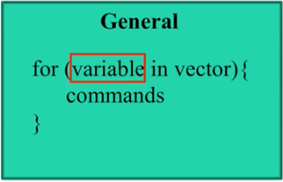

which is coded as:

```r
for(i in 1:10){
  print(i)
}
```

What is the output of this loop?

### Exponential Model at t+100

For loop syntax is:

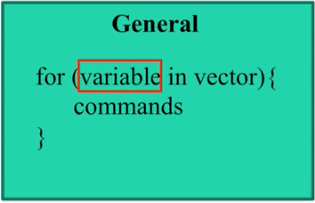

which is coded as:

```r
for(i in 1:10){
  print(i)
}
```

```
[1] 1
[1] 2
[1] 3
[1] 4
[1] 5
[1] 6
[1] 7
[1] 8
[1] 9
[1] 10
```

### Exponential Model at t to t+100

Starting with a vector `N.seq` where `N.seq[1]`\( =N_t \) use the `N.seq[i]` and `N.seq[i+1]` to finish this loop.

```r
N.seq <- c(rep(0,100)) # make a vector where the calculations will be stored.
N.seq[1] <- 10 # set the current population size to 10

for(i in 1:100){
    # command to iterate N_t+1 calculation
}

N.seq # N at N_t through N_t+100
```

### Exponential Model at t to t+100

Here we are using the value at \( N_t \) (`N.seq[i]`) to calculate the value at the next time step \( N_{t+1} \) which is saved in the next spot of the `N.seq` vectors at `N.seq[i+1]`

```r
N.seq <- c(rep(0,100)) # make a vector where the calculations will be stored.
N.seq[1] <- 10 # set the current population size to 10

for(i in 1:100){
    N.seq[i+1] <- N.seq[i] + (r*N.seq[i])
}

N.seq # vector of N at N_t through N_t+100
```

*Concept check: what would N.seq look like if the for command was changed to for(i in 1:50)?*

**You should be able to…**

- iterate a calculation
- simulate populations based on an ODE
- write a function
- create an HTML doc with code and commentary
- write code following best practices
- calculate summary statistics of a dataset
- create a figure from data

**Next**

- Data visualization
- Statistical analysis

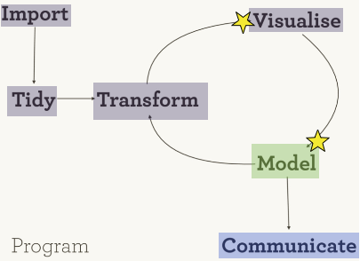